# Practical Machine Learning project

C. DiMarco

2/21/2020

## Introduction

The goal of this project is to predict the manner in which they did the exercise. This is the “classe” variable in the training set. We use most of the other variables to predict with.

## Preliminaries and first round of cross-validation

Read in the training data, then partition into 75% training and 25% testing sets (first round of cross-validation, as per usual in the lectures).

```r
setwd("~/coursera/practical machine learning/Practical Machine Learning")

if(!require(caret)){
    library(caret)
    library(knitr)
    library(randomForest)
}
trainingData <- read.csv("pml-training.csv")
#Check what data look like without NAs
trainingDataLite <- read.csv("pml-training.csv")
set.seed(333)
inTrain <- createDataPartition(trainingData$classe, p = 0.75, list = FALSE)
training <- trainingData[inTrain, ]
testing <- trainingData[-inTrain, ]
```

## Exploratory

Many varaibles are missing most values.

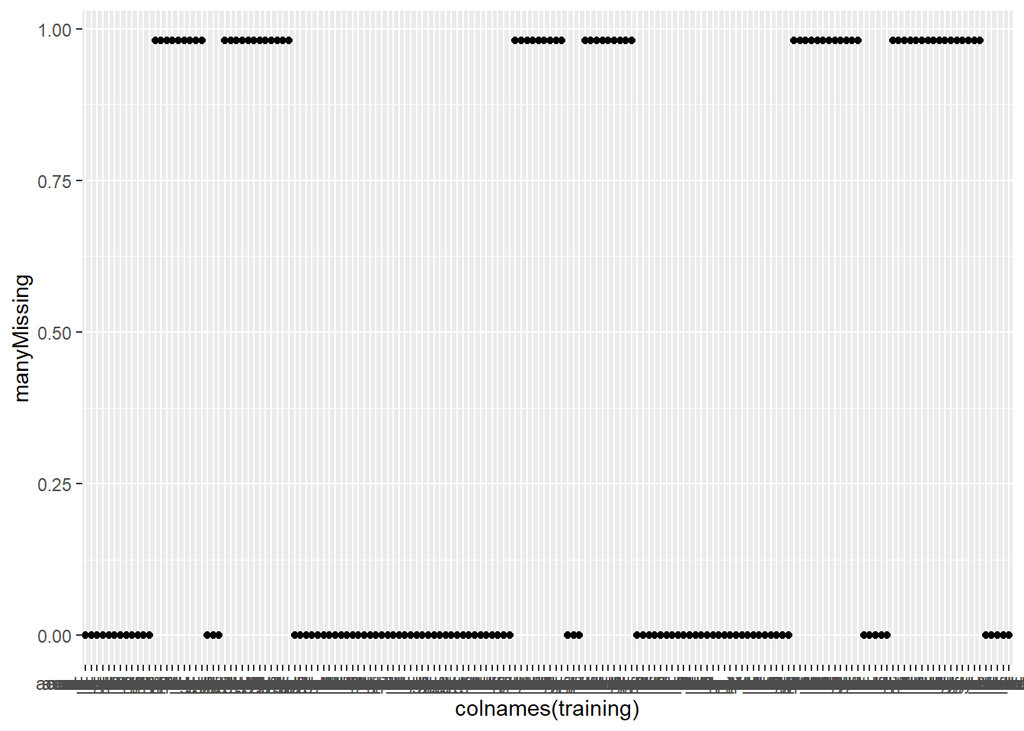

```r
#Function to compute the NA percentage of a variable x
percentMissing <- function(x) {
  sum(is.na(x))/length(x)
}

#Determine which variables are more than 50% missing.
manyMissing <- apply(training, MARGIN = 2, FUN = percentMissing)
qplot(x = colnames(training), y = manyMissing)
```

```r
  #There are lots.
  mostlyMissingVariables <- colnames(training)[manyMissing > 0.5]
  cat("There are", length(mostlyMissingVariables), "variables missing",
      "more than 50% of their values.")
```

```
## There are 67 variables missing more than 50% of their values.
```

## Pre-processing

### 1. Remove variables that are almost entirely missing.

```r
training <- training[, manyMissing <= 0.05]
testing <- testing[, manyMissing <= 0.05]
```

### 2. Remove non-predictors

The variable X simply numbers the rows, so may be disregarded. Similarly the timestamps appear to be irrelevant.

Each of the 6 participants performed 10 repetitions in 5 fashions (classes), so the classe does not depend on the user_name in a meaningful way. Therefore user_name should be eliminated as a predictor.

```r
training <- training[, -c(1:5)]
testing <- testing[, -c(1:5)]
#qplot(new_window, classe, data = training)
```

### 3. Check which variales have near-zero variance.

Remove all numeric variables from the training and testing sets that exhibit near-zero variance in the training set.

```r
nsv <- nearZeroVar(training, saveMetrics = TRUE)
training <- training[ , nsv$nzv == FALSE]
testing <- testing[ , nsv$nzv == FALSE]
```

### 4. Do KNN imputation to all variables except the response variable classe.

```r
classeIndex <- dim(training)[2]  #column index for classe variable
preObj <- preProcess(training[, -classeIndex], method = "knnImpute")
trainImp <- predict(preObj, training[, -classeIndex])
#Now put classe back into data frame to fit the model with multinomial logistic regression later
trainImpFinal <- cbind(trainImp, training$classe)
colnames(trainImpFinal)[classeIndex] <- "classe"
```

## Fit several standard classification models

```r
control <- trainControl(method = "cv", number = 10)
metric <- "Accuracy"
```

### classification tree

```r
set.seed(7)
modFitTree <- train(classe ~.,
                data = trainImpFinal,
                method = "rpart",
                trControl = control,
                metric = metric)
```

### linear discriminant analysis

```r
set.seed(7)
modFitLda <- train(classe ~.,
                data = trainImpFinal,
                method = "lda",
                trControl = control,
                metric = metric)
```

### k-nearest neighbors

```r
set.seed(7)
modFitKnn <- train(classe ~.,
                data = trainImpFinal,
                method = "knn",
                trControl = control,
                metric = metric)
```